# Time Series: A First Course with Bootstrap Starter

# Lesson 3-1: Nonparametric Smoothing

- The filtering of time series uses some concepts from nonparametric smoothing.

## Nonparametric Regression

- We might think of the time series mean $\mu_t = {\mathbb E} [X_t]$ as an arbitary, smoothly varying function.
- A very simple case:
  $$X_t = \mu_t + Z_t$$
  with $Z_t \sim i.i.d. (0, \sigma^2)$.
- We may estimate $\mu_t$ via averaging over neighboring values, e.g.,
  $$\widehat{\mu}_t = \frac{1}{2m+1} \sum_{k = -m}^m X_{t-k}.$$
  This works because
  $$\widehat{\mu}_t = \frac{1}{2m+1} \sum_{k = -m}^m \mu_{t-k} +
  \frac{1}{2m+1} \sum_{k = -m}^m Z_{t-k},$$
  and the first term is approximately equal to $\mu_t$ if $m$ is small and the mean is smooth (not changing too much over time). Also, the second term has mean zero and variance $\sigma^2/(2m+1)$, which tends to zero as $m$ increases to $\infty$.
- So bias is lower for small $m$, but variance is lower for large $m$, creating a tension.

## Kernel and Bandwidth

- Above, we have equal weights on the observations. We can have unequal weights, through the device of a *kernel*, which is a function that weights the data.
- The *bandwidth* $m$ defines a neighborhood of values around time $t$, for which we use the kernel’s weights.
- Large bandwidth yields more smoothing, with suppression of local features.
- Small bandwidth yields less smoothing, with higher variability.

## Edge Effects

- We can only compute $\widehat{\mu}_t$ for $t = m+1, \ldots, n-m$. So the values for $t = 1, \ldots, m$ and $t = n-m+1, \ldots, n$ are “missing”.
- Sometimes this so-called “edge effect” is addressed by designing asymmetric smoothing at the boundaries.
- Often the edge effects are ignored, when we are interested in the interior of the time series sample.

### Nonparametric Regression for Population

- Apply the nonparametric regression technique with $m=20$ to U.S. population data.
- First, we write a function to do local averaging.

```r
simple.ma <- function(x,m)
{
    weights <- rep(1,2*m+1)/(2*m+1)
    n <- length(x)
    trend <- NULL
    for(t in (m+1):(n-m))
    {
        trend <- c(trend,sum(x[(t-m):(t+m)]*weights))
    }
    trend <- c(rep(NA,m),trend,rep(NA,m))
    return(trend)
}
```

- Then we apply this to the data.

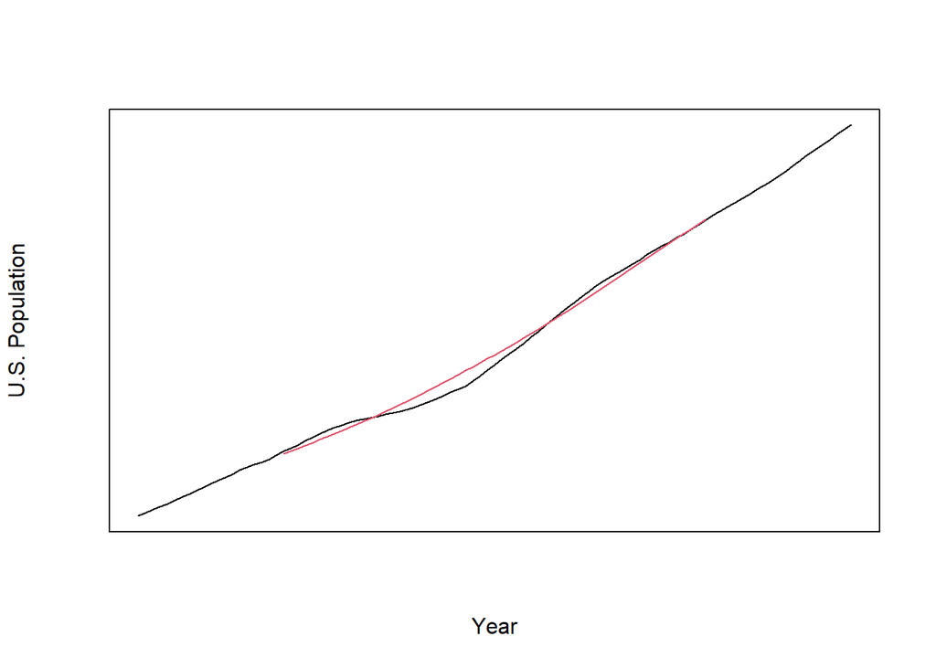

```r
pop <- read.table("USpop.dat")
pop <- ts(pop, start = 1901)
m <- 20
pop.trend <- simple.ma(pop,m)
plot(pop,xlab="Year",ylab="U.S. Population",col=1,lwd=1,yaxt="n",xaxt="n")
lines(ts(pop.trend,start=1901,frequency=1),lty=1,lwd=1,col=2)
```